# DEBATE 1

Dani Ibañez

1/3/2021

### PREGUNTA 1: Ejemplo Estudio Microarrays

#### **Título del Estudio**

Combined Use of Laser Capture Microdissection and cDNA Microarray Analysis Identifies Locally Expressed Disease-Related Genes in Focal Regions of Psoriasis Vulgaris Skin Lesions

#### **Tipo de Microarrays**

Affymetrix HGU133A 2.0

The GeneChip™ Human Genome U133A 2.0 Array is a **single array** representing **14,500 well-characterized human genes** that can be used to explore human biology and disease processes.

#### **Número de muestras y grupos**

Paired lesional and non-lesional samples from 7 psoriatic patients were used. Samples from the first four patients were used in the single vs. double amplification comparison. Samples from the remaining three patients were subjected to LCM. NOTA: dos métodos de visualización de muestras de 7 pacientes.

#### **Objetivo del estudio**

La psoriasis vulgar es una enfermedad compleja caracterizada por alteraciones en el crecimiento y diferenciación de los queratinocitos epidérmicos, así como un marcado aumento de las poblaciones de leucocitos.

En este estudio, se utiliza microdisección por captura láser (LCM) y análisis de matriz de genes para estudiar la expresión génica de las células en la epidermis y dermis lesionadas, en comparación con las regiones no lesionadas correspondientes.

Usando este enfoque, se detectan 1800 productos génicos expresados de forma diferencial en la epidermis o dermis de las zonas con psoriasis. En concreto este estudio detectó una producción local de CCL19, una quimiocina organizadora linfoide, y su receptor CCR7 en agregados dérmicos psoriásicos, junto con la presencia de productos génicos LAMP3 / DC-LAMP y CD83, que tipifican las CD maduras.

En conclusión, los patrones de expresión génica obtenidos con LCM y análisis de microarrays junto con la detección de células T y DC mediante tinción inmune sugieren un posible mecanismo para la organización linfoide a través de CCL19 / CCR7 en la piel enferma.

#### **Enlace de datos y artículo**

https://www.ncbi.nlm.nih.gov/pmc/articles/PMC3352975/

Gene Expression Omnibus repository (**GSE26866**)

https://www.ncbi.nlm.nih.gov/geo/query/acc.cgi?acc=GSE26866

### PREGUNTA 2: Estudio base

#### **Introducción a Biobase**

Como personalmente me ha costado mucho entenderlo todo y al final creo que lo he conseguido, aunque me extienda, comparto la información que he encontrado.Disculpad si a alguien le parece obvio. A mi se me mezclaban nombres, funciones, clases, de todo.

La primera idea importante es que Biobase tiene las funciones para acceder, leer y escribir en un ExpressionSet. Pero lo que me costó es entender es que también incluye 3 archivos o datasets de ejemplo relacionados con microarrays. Son los siguientes:

- aaMap
- sample.ExpressionSet
- geneData

Creo que cuando uno está aprendiendo los comandos y funciones R de acceso, es fácil confundir nombres de ejemplos y datos con nombres de instrucciones de R. De hecho en cualquier trabajo en R, a veces es muy útil y clarifica ideas el utilizar nombres de los datos y objetos en español para distinguirlo de los nombres de las funciones en R, siempre en inglés, especialmente cuando uno empieza a programar con paquetes nuevos.

En cualquier caso, lo primero es saber que hay un ExpressionSet de ejemplo en Biobase que se llama **sample.ExpressionSet**.

La segunda cuestión importante es el nombre **“extdata”** que aparece en varias ocasiones. Investigando he visto que **extdata** es el nombre de un directorio usado para grabar archivos descargados mediante funciones de R. Me puse a mirar qué tenía yo en mi ordenador con el nombre **extdata** y me salieron decenas de directorios con ese nombre.

Pues bien, de nuevo Biobase, al instalarse el paquete, genera un directorio “/Biobase/extdata/” donde guarda dos archivos TXT:

- exprsData.txt
- pData.txt

Por lo tanto, este nombre “extdata” que parecía inventado, resulta ser el directorio donde se guardan unos archivos TXT incluidos en el paquete Biobase, que por otra parte, no he sabido ver dónde lo cuentan que existen. De hecho en la ayuda de Biobase diria que no los menciona.

Pues resulta que estos archivos TXT son los archivos planos, separados por tabuladores que se leen mediante la función **read.table()** función que en principio si que todos conocemos. La función **system.file()** simplemente busca el directorio donde se encuentran dichos archivos.

Finalmente comentar que por un lado podemos leer directamente los archivos TXT anteriores para montar el ExpressionSet, pero podemos consultarlos directamente mediante los datasets comentados anteriormente. En efecto:

- Si cargamos **data(geneData)** estamos trabajando con el archivo **exprsData.txt**
- Si cargamos **data(sample.ExpressionSet)** estamos trabajando con los mismos datos que con **pData.txt**

Abordamos pues el código R para trabajar…

#### **Análisis del ejemplo incluido en Biobase**

```r
#if (!require("BiocManager"))
# + install.packages("BiocManager")
# BiocManager::install("Biobase","methods")

library(Biobase)
library(knitr)


# Extraemos los datos del archivo exprsData.txt en la matriz exprs


Directorio_txt <- system.file("extdata", package="Biobase")
exprsFile <- file.path(Directorio_txt, "exprsData.txt")
exprs <- as.matrix(read.table(exprsFile, header = TRUE, sep = "\t", row.names = 1, as.is=TRUE))


# Extraemos los datos del archivo pData.txt en la tabla pData


FenoMuestras <- file.path(Directorio_txt, "pData.txt")
pData <- read.table(FenoMuestras, header = TRUE, sep = "\t", row.names = 1, as.is=TRUE)
```

```r
class(exprs) # exprs es un array. No entiendo porque se pasa a Array.
```

```
[1] "matrix" "array"
```

```r
head(exprs,4)
```

```
                       A         B        C        D        E       F        G
AFFX-MurIL2_at  192.7420  85.75330 176.7570 135.5750 64.49390 76.3569 160.5050
AFFX-MurIL10_at  97.1370 126.19600  77.9216  93.3713 24.39860 85.5088  98.9086
AFFX-MurIL4_at   45.8192   8.83135  33.0632  28.7072  5.94492 28.2925  30.9694
AFFX-MurFAS_at   22.5445   3.60093  14.6883  12.3397 36.86630 11.2568  23.0034
                      H       I         J        K       L       M       N
AFFX-MurIL2_at  65.9631 56.9039 135.60800 63.44320 78.2126 83.0943 89.3372
AFFX-MurIL10_at 81.6932 97.8015  90.48380 70.57330 94.5418 75.3455 68.5827
AFFX-MurIL4_at  14.7923 14.2399  34.48740 20.35210 14.1554 20.6251 15.9231
AFFX-MurFAS_at  16.2134 12.0375   4.54978  8.51782 27.2852 10.1616 20.2488
                      O       P        Q        R         S       T         U
AFFX-MurIL2_at  91.0615 95.9377 179.8450 152.4670 180.83400 85.4146 157.98900
AFFX-MurIL10_at 87.4050 84.4581  87.6806 108.0320 134.26300 91.4031  -8.68811
AFFX-MurIL4_at  20.1579 27.8139  32.7911  33.5292  19.81720 20.4190  26.87200
AFFX-MurFAS_at  15.7849 14.3276  15.9488  14.6753  -7.91911 12.8875  11.91860
                       V       W         X       Y         Z
AFFX-MurIL2_at  146.8000 93.8829 103.85500 64.4340 175.61500
AFFX-MurIL10_at  85.0212 79.2998  71.65520 64.2369  78.70680
AFFX-MurIL4_at   31.1488 22.3420  19.01350 12.1686  17.37800
AFFX-MurFAS_at   12.8324 11.1390   7.55564 19.9849   8.96849
```

```r
colnames(exprs)
```

```
 [1] "A" "B" "C" "D" "E" "F" "G" "H" "I" "J" "K" "L" "M" "N" "O" "P" "Q" "R" "S"
[20] "T" "U" "V" "W" "X" "Y" "Z"
```

```r
dim(exprs)
```

```
[1] 500  26
```

```r
class(pData) # pData ess un dataframe
```

```
[1] "data.frame"
```

```r
head(pData,10)
```

```
  gender    type score
A Female Control  0.75
B   Male    Case  0.40
C   Male Control  0.73
D   Male    Case  0.42
E Female    Case  0.93
F   Male Control  0.22
G   Male    Case  0.96
H   Male    Case  0.79
I Female    Case  0.37
J   Male Control  0.63
```

```r
colnames(pData)
```

```
[1] "gender" "type"   "score"
```

```r
dim(pData)
```

```
[1] 26  3
```

```r
str(pData)
```

```
'data.frame':   26 obs. of  3 variables:
 $ gender: chr  "Female" "Male" "Male" "Male" ...
 $ type  : chr  "Control" "Case" "Control" "Case" ...
 $ score : num  0.75 0.4 0.73 0.42 0.93 0.22 0.96 0.79 0.37 0.63 ...
```

```r
# Las columnas de exprs son las filas de pData?

all(colnames(exprs)==rownames(pData))
```

```
[1] TRUE
```

Por otra parte podemos acceder directamente a los datos mediante la carga de geneData y sample.ExpresionSet.

```r
data(sample.ExpressionSet)
muestras <- sample.ExpressionSet
colnames(muestras)
```

```
 [1] "A" "B" "C" "D" "E" "F" "G" "H" "I" "J" "K" "L" "M" "N" "O" "P" "Q" "R" "S"
[20] "T" "U" "V" "W" "X" "Y" "Z"
```

```r
dim(muestras)
```

```
Features  Samples
     500       26
```

Podemos montar el archivo de descripción general del estudio:

```r
info_experimento <- new("MIAME",
name="Dani Ibanez",
lab="laboratorio Uoc",
contact="dani@gmail.com",
title="psoriasis studies",
abstract="different gene expression in Non lesioned and lesioned skin",
url="www.psoriasis.uoc.com")
```

#### **Creación del elemento ExpressionSet a partir de los 4 bloques de datos:**

```r
FenoData <- new("AnnotatedDataFrame", data=pData)
ejemploSet <- ExpressionSet(assayData = exprs, phenoData=FenoData, experimentData=info_experimento,annotation="GPL571")
```

#### **Leyendo y manipulando datos del ExpressionSet creado**

```r
featureNames(ejemploSet)[1:10]
```

```
 [1] "AFFX-MurIL2_at"  "AFFX-MurIL10_at" "AFFX-MurIL4_at"  "AFFX-MurFAS_at"
 [5] "AFFX-BioB-5_at"  "AFFX-BioB-M_at"  "AFFX-BioB-3_at"  "AFFX-BioC-5_at"
 [9] "AFFX-BioC-3_at"  "AFFX-BioDn-5_at"
```

```r
sampleNames(ejemploSet)
```

```
 [1] "A" "B" "C" "D" "E" "F" "G" "H" "I" "J" "K" "L" "M" "N" "O" "P" "Q" "R" "S"
[20] "T" "U" "V" "W" "X" "Y" "Z"
```

```r
sampleNames (ejemploSet) <- c(1:26)
sampleNames(ejemploSet)
```

```
 [1] "1"  "2"  "3"  "4"  "5"  "6"  "7"  "8"  "9"  "10" "11" "12" "13" "14" "15"
[16] "16" "17" "18" "19" "20" "21" "22" "23" "24" "25" "26"
```

```r
varLabels(ejemploSet)
```

```
[1] "gender" "type"   "score"
```

```r
varLabels(ejemploSet)[1]="sexo"
varLabels(ejemploSet)
```

```
[1] "sexo"  "type"  "score"
```

```r
head(exprs(ejemploSet)[,c(1,24,26)])
```

```
                       1        24        26
AFFX-MurIL2_at  192.7420 103.85500 175.61500
AFFX-MurIL10_at  97.1370  71.65520  78.70680
AFFX-MurIL4_at   45.8192  19.01350  17.37800
AFFX-MurFAS_at   22.5445   7.55564   8.96849
AFFX-BioB-5_at   96.7875  57.57380  61.70440
AFFX-BioB-M_at   89.0730  41.82090  49.41220
```

```r
exprs(ejemploSet)[2,26]=9999
head(exprs(ejemploSet)[,c(1,24,26)])
```

```
                       1        24         26
AFFX-MurIL2_at  192.7420 103.85500  175.61500
AFFX-MurIL10_at  97.1370  71.65520 9999.00000
AFFX-MurIL4_at   45.8192  19.01350   17.37800
AFFX-MurFAS_at   22.5445   7.55564    8.96849
AFFX-BioB-5_at   96.7875  57.57380   61.70440
AFFX-BioB-M_at   89.0730  41.82090   49.41220
```

### **Una propuesta gráfica como resumen de lo que es ExpressionSet**

Para finalizar, he intentado realizar un resumen gráfico de lo que es un ExpressionSet, con comentarios. Seguro que hay errores, por lo que pido que se tome como un simple ejercicio de síntesis para ser revisado, rectificado y mejorado.

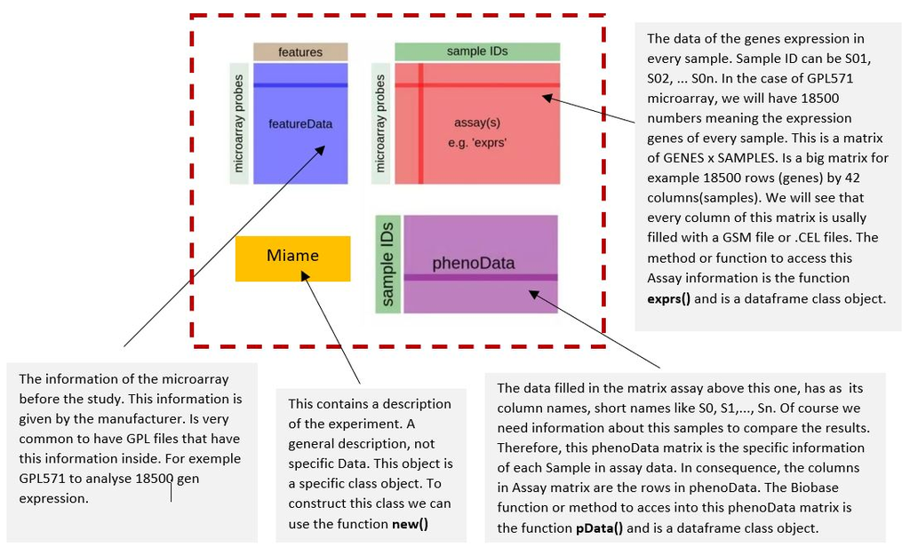

```r
knitr::include_graphics("c:/MASTER/OMICAS/Estruct_Exprs2.jpg")
```

### PREGUNTA 3: Estudio GEOquery Package

#### **Introducción a Geoquery**

El estudio que hemos elegido en el primer apartado está basado en el microarray U133A 2.0 que se define en el paquete GPL571

Por ejemplo, yo puedo buscar para un tipo concreto de microarray, los estudios que han sido registrados. De este modo me puede servir de guia para el mio, o poder comparar otros datos que quizá enriquecen el mio. En el enlace siguiente

https://www.ncbi.nlm.nih.gov/geo/query/acc.cgi?acc=GPL571

Por ejemplo, si buscamos como palabra clave “psoriasis” encontramos 8 estudios realizados con este modelo de microaarray GPL571:

GSE11903  
GSE20264  
**GSE26866**  
GSE30768  
GSE31652  
GSE32407  
GSE42305  
GSE52471

Si clicamos en nuestro estudio concreto tenemos la información básica del estudio ya plasmada en el ejercicio 1:

https://www.ncbi.nlm.nih.gov/geo/query/acc.cgi?acc=GSE26866

Si vemos el detalle, estamos hablando de 7 pacientes pero el análisis es sobre 37 muestras distintas combinando distintos factores

Factor 1: NL y LS Factor 2: Whole single, Whole Double, Double Factor 3: RD, EPI, PD, ICs

El estudio no trabaja sobre todas las combinaciones. En concreto estudia el resultado de 37 muestras que dan origen a 37 archivos GSM:

(P1:P7)+(NL,LS)+Whole Double = 7x2x1 = 14 muestras  
(P1:P4)+(NL+LS)+Whole Single = 4x2x1 = 8 muestras  
(P5:P7)+(NL-RD,NL-EPI,LS-PD,LS-EPI,LS-ICp)+Double = 3x5x1 = 15 muestras

Al final de la página web del estudio GSE26866 encontramos la posibilidad de descargar todos los 37 archivos GSM o seleccionar cuales de ellos nos interesan.

Sobre cada GSM podemos obtener información detallada del archivo. Por ejemplo vemos la de GSM661400:

https://www.ncbi.nlm.nih.gov/geo/query/acc.cgi?acc=GSM661400

> Status Public on Jan 30, 2012  
> Title 1_NL_whole_Double  
> Sample type RNA  
> Source name 1, NL, whole, Double  
> Organism Homo sapiens  
> Characteristics tissue: non-lesional psoriatic skin  
> patient: 1  
> condition: **Non-Lesional**  
> region: **whole**  
> amplification: **Double**  
> material: block  
> Extracted molecule total RNA  
> Extraction protocol QIAGEN Rneasy Kit  
> Label biotin  
> Label protocol Affymetrix single and double amplification protocol

Este archivo incluye directamente la tabla de valores obtenidos en el Array con una tabla de 22277 registros de los cuales unos pocos son de control y header.

vamos con el código del estudio:

#### **Introducción a GEOquery**

```r
library(GEOquery)
psoriasisT <- getGEO("GSE26866",GSEMatrix=TRUE) # si no se indica por defecto es TRUE

class(psoriasisT)
```

```
[1] "list"
```

```r
# Es importante ver que psoriasisT es de classe List con un solo elemento. Pueden existir estudios con varios subestudios dentro.
# Realizamos la extracción del primer y único elemento de la lista mediante el doble corchete [[1]]

psoriasis <- psoriasisT[[1]]

class(psoriasis)
```

```
[1] "ExpressionSet"
attr(,"package")
[1] "Biobase"
```

```r
# psoriasis ya es un elemento de tipo ExpressionSet y por lo tanto ya podemos aplicar las funciones típicas de este tipo para acceder a los datos. Antes vemos todos los elementos simplemento citando el elemento:

psoriasis
```

```
ExpressionSet (storageMode: lockedEnvironment)
assayData: 22277 features, 37 samples
  element names: exprs
protocolData: none
phenoData
  sampleNames: GSM661382 GSM661387 ... GSM661428 (37 total)
  varLabels: title geo_accession ... tissue:ch1 (40 total)
  varMetadata: labelDescription
featureData
  featureNames: 1007_s_at 1053_at ... AFFX-TrpnX-M_at (22277 total)
  fvarLabels: ID GB_ACC ... Gene Ontology Molecular Function (16 total)
  fvarMetadata: Column Description labelDescription
experimentData: use 'experimentData(object)'
  pubMedIds: 22402443
Annotation: GPL571
```

#### **Estructra de datos de ExpressionSet y acceso a sus datos**

Al mostrar el interior del elemento psoriasis vemos que tenemos un montón de elementos a los que acceder:

```r
# Acceso a la Tabla PhenoData usando el comando pData()

# Dimensiones de la tabla pData (40 datos de información para cada una de las 37 muestras)

dim(pData(psoriasis))
```

```
[1] 37 40
```

```r
# Nombres de las columnas de pData (40 columnas de información de cada muestra)

colnames(pData(psoriasis))
```

```
 [1] "title"                   "geo_accession"
 [3] "status"                  "submission_date"
 [5] "last_update_date"        "type"
 [7] "channel_count"           "source_name_ch1"
 [9] "organism_ch1"            "characteristics_ch1"
[11] "characteristics_ch1.1"   "characteristics_ch1.2"
[13] "characteristics_ch1.3"   "characteristics_ch1.4"
[15] "characteristics_ch1.5"   "molecule_ch1"
[17] "extract_protocol_ch1"    "label_ch1"
[19] "label_protocol_ch1"      "taxid_ch1"
[21] "hyb_protocol"            "scan_protocol"
[23] "data_processing"         "platform_id"
[25] "contact_name"            "contact_email"
[27] "contact_institute"       "contact_address"
[29] "contact_city"            "contact_state"
[31] "contact_zip/postal_code" "contact_country"
[33] "supplementary_file"      "data_row_count"
[35] "amplification:ch1"       "condition:ch1"
[37] "material:ch1"            "patient:ch1"
[39] "region:ch1"              "tissue:ch1"
```

```r
# Contenido de pData por ejemplo, de las 10 primeras muestras, vamos a ver por ejemplo 4 campos concretos (1,3,6 y 10)

pData(psoriasis)[1:10,c(1,3,6,10)]
```

```
                      title                status type
GSM661382 1_NL_whole_Single Public on Jan 30 2012  RNA
GSM661387 1_LS_whole_Single Public on Jan 30 2012  RNA
GSM661389 2_NL_whole_Single Public on Jan 30 2012  RNA
GSM661391 2_LS_whole_Single Public on Jan 30 2012  RNA
GSM661393 3_NL_whole_Single Public on Jan 30 2012  RNA
GSM661394 3_LS_whole_Single Public on Jan 30 2012  RNA
GSM661396 4_NL_whole_Single Public on Jan 30 2012  RNA
GSM661398 4_LS_whole_Single Public on Jan 30 2012  RNA
GSM661400 1_NL_whole_Double Public on Jan 30 2012  RNA
GSM661401 1_LS_whole_Double Public on Jan 30 2012  RNA
                          characteristics_ch1
GSM661382 tissue: non-lesional psoriatic skin
GSM661387     tissue: lesional psoriatic skin
GSM661389 tissue: non-lesional psoriatic skin
GSM661391     tissue: lesional psoriatic skin
GSM661393 tissue: non-lesional psoriatic skin
GSM661394     tissue: lesional psoriatic skin
GSM661396 tissue: non-lesional psoriatic skin
GSM661398     tissue: lesional psoriatic skin
GSM661400 tissue: non-lesional psoriatic skin
GSM661401     tissue: lesional psoriatic skin
```

```r
# Ahora accedemos al archivo de expresión génica mediante el comando exprs(). Aquí están los datos del experimento.
# Podemos ver que son 37 muestras y 22777 registros correspondientes a niveles de expresión.

dim(exprs(psoriasis))
```

```
[1] 22277    37
```

```r
# Nombres de las columnas de assayData (son los 37 nombres de los archivos GSM correspondientes a las 37 muestras)

colnames(exprs(psoriasis))
```

```
 [1] "GSM661382" "GSM661387" "GSM661389" "GSM661391" "GSM661393" "GSM661394"
 [7] "GSM661396" "GSM661398" "GSM661400" "GSM661401" "GSM661402" "GSM661403"
[13] "GSM661404" "GSM661405" "GSM661406" "GSM661407" "GSM661408" "GSM661409"
[19] "GSM661410" "GSM661411" "GSM661412" "GSM661413" "GSM661414" "GSM661415"
[25] "GSM661416" "GSM661417" "GSM661418" "GSM661419" "GSM661420" "GSM661421"
[31] "GSM661422" "GSM661423" "GSM661424" "GSM661425" "GSM661426" "GSM661427"
[37] "GSM661428"
```

```r
# Contenido de exprs por ejemplo, de los genes (parametros) en las posiciones 1000 a 1005, vemos los valores sobre las primeras 5 muestras del SET

exprs(psoriasis)[1000:1005,1:5]
```

```
            GSM661382 GSM661387 GSM661389 GSM661391 GSM661393
201472_at    9.143651  9.519384  9.269360  9.529526  9.107479
201473_at    7.076408  8.909844  8.845188  9.499726  8.336031
201474_s_at  7.430625  6.906387  6.774663  7.955132  7.046572
201475_x_at  8.499540  9.239606  8.459980  9.383954  8.546473
201476_s_at  6.170180  7.389809  6.796147  7.356728  7.002519
201477_s_at  9.925533 10.832040 10.074010 10.233770 10.207740
```

```r
# información del microarray

annotation(psoriasis)
```

```
[1] "GPL571"
```

```r
# Descripción del experimento

experimentData(psoriasis)
```

```
Experiment data
  Experimenter name: Mayte,,Suarez-Farinas
  Laboratory:
  Contact information: mayte.suarezfarinas@mssm.edu
  Title: Combined Use of Laser Capture Microdissection and Microarray Analysis Identifies Locally Expressed Disease-Related Genes in Focal Regions of Psoriasis Vulgaris Skin Lesions
  URL: https://www.ncbi.nlm.nih.gov/geo/query/acc.cgi?acc=GSE26866
  PMIDs: 22402443

  Abstract: A 50 word abstract is available. Use 'abstract' method.
  notes:
   contact_address:
      1425 Madison Ave, L2-70C, Box 1077,
   contact_city:
      New York
   contact_country:
      USA
   contact_email:
      mayte.suarezfarinas@mssm.edu
   contact_institute:
      Mount SinaiSchool of Medicine
   contact_name:
      Mayte,,Suarez-Farinas
   contact_state:
      NY
   contact_zip/postal_code:
      10075
   contributor:
      Hiroshi,,Mitsui
Mayte,,SuÃ¡rez-FariÃ±as
James,G,Krueger
   geo_accession:
      GSE26866
   last_update_date:
      Dec 06 2018
   overall_design:
      For the comparison of gene expression patterns between single and double a
mplification techniques, total RNA was extracted from blocks of paired les
ional and non-lesional psoriatic skin biopsies from four patients.
For LCM
 experiment, total RNA was extracted from sliced tissue sections of paired
```

[output cut: 21 more lines]

```
   summary:
      In this study, we sought to establish the usefulness of LCM on cDNA microa
rray analysis. We reported that LCM samples improved the sensitivity of de
tection of differentially expressed genes over conventional bulk tissue an
alysis. We also provided the new information of chemokine and its receptor
 interaction within psoriatic lesional skin.
   supplementary_file:
      ftp://ftp.ncbi.nlm.nih.gov/geo/series/GSE26nnn/GSE26866/suppl/GSE26866_RAW
.tar
   title:
      Combined Use of Laser Capture Microdissection and Microarray Analysis Iden
tifies Locally Expressed Disease-Related Genes in Focal Regions of Psorias
is Vulgaris Skin Lesions
   type:
      Expression profiling by array
```